# Practical Machine Learning Course Project

# Overview

Using devices such as Jawbone Up, Nike FuelBand, and Fitbit it is now possible to collect a large amount of data about personal activity relatively inexpensively. These type of devices are part of the quantified self movement. One thing that people regularly do is quantify how much of a particular activity they do, but they rarely quantify how well they do it. In this report we will use data from accelerometers on the belt, forearm, arm, and dumbell of 6 participants. They were asked to perform barbell lifts correctly and incorrectly in 5 different ways. The data is available from the HAR study website at http://groupware.les.inf.puc-rio.br/har

A random forest fit model based on collected sensor data will be used to predict the manner in which the users did the exercise, based on a 5 level classification (from “A” to “E”).

# Predictor selection and exploratory data analysis

The available data from the HAR website includes a training set composed of 19622 observations and 160 columns. Several of these columns include NA values and there are some occurrences of #DIV/0! values that will also be treated as NA. A validation sample of 20 observations will be loaded and cleaned in order to be used as the final step of the study (see last section).

```r
require(data.table)
training <- fread("https://d396qusza40orc.cloudfront.net/predmachlearn/pml-training.csv",
                  data.table=TRUE, header=TRUE, sep=",", na.strings=c("NA", "#DIV/0!"))
# training <- fread("./pml-training.csv", data.table=TRUE) # Local load
validation <- fread("https://d396qusza40orc.cloudfront.net/predmachlearn/pml-testing.csv",
                 data.table=TRUE, header=TRUE, sep=",", na.strings=c("NA", "#DIV/0!"))
str(training)
```

```
## Classes 'data.table' and 'data.frame':   19622 obs. of  160 variables:
##  $ V1                      : chr  "1" "2" "3" "4" ...
##  $ user_name               : chr  "carlitos" "carlitos" "carlitos" "carlitos" ...
##  $ raw_timestamp_part_1    : int  1323084231 1323084231 1323084231 1323084232 1323084232 1323084232 1323084232 1323084232 1323084232 1323084232 ...
##  $ raw_timestamp_part_2    : int  788290 808298 820366 120339 196328 304277 368296 440390 484323 484434 ...
##  $ cvtd_timestamp          : chr  "05/12/2011 11:23" "05/12/2011 11:23" "05/12/2011 11:23" "05/12/2011 11:23" ...
##  $ new_window              : chr  "no" "no" "no" "no" ...
##  $ num_window              : int  11 11 11 12 12 12 12 12 12 12 ...
##  $ roll_belt               : num  1.41 1.41 1.42 1.48 1.48 1.45 1.42 1.42 1.43 1.45 ...
##  $ pitch_belt              : num  8.07 8.07 8.07 8.05 8.07 8.06 8.09 8.13 8.16 8.17 ...
##  $ yaw_belt                : num  -94.4 -94.4 -94.4 -94.4 -94.4 -94.4 -94.4 -94.4 -94.4 -94.4 ...
##  $ total_accel_belt        : int  3 3 3 3 3 3 3 3 3 3 ...
##  $ kurtosis_roll_belt      : chr  "" "" "" "" ...
##  $ kurtosis_picth_belt     : chr  "" "" "" "" ...
##  $ kurtosis_yaw_belt       : chr  "" "" "" "" ...
```

[output cut: 87 more lines]

Taking a closer look at the data set, 107 of the columns contain information related to timestamp, exercise window and calculated statistical variables based on sensor data (kurtosis, standard deviation, skewdness, etc.). This study will only focus on predictors related to pure sensor data. Thus, all the other columns will be discarded prior to partitioning data for training and testing the model.

```r
isNotPredictor <- grepl("V1|user|timestamp|window|kurtosis|skewness|max|min|amplitude|avg|stddev|var", names(training))
predictors <- names(training)[!isNotPredictor]
training2 <- training[, predictors, with=F]
length(names(training2))
```

```
## [1] 53
```

The “classe” column to predict is a categorical variable with values from “A” to “E” that will be formatted as a factor variable. Moreover, the rest of the predictors (numeric sensor data) will be homogenized to numeric class.

```r
training2$classe <- as.factor(training2$classe)
training2 <- training2[, (c(1:52)) := lapply(.SD, as.numeric), .SDcols = c(1:52)]
str(training2)
```

```
## Classes 'data.table' and 'data.frame':   19622 obs. of  53 variables:
##  $ roll_belt           : num  1.41 1.41 1.42 1.48 1.48 1.45 1.42 1.42 1.43 1.45 ...
##  $ pitch_belt          : num  8.07 8.07 8.07 8.05 8.07 8.06 8.09 8.13 8.16 8.17 ...
##  $ yaw_belt            : num  -94.4 -94.4 -94.4 -94.4 -94.4 -94.4 -94.4 -94.4 -94.4 -94.4 ...
##  $ total_accel_belt    : num  3 3 3 3 3 3 3 3 3 3 ...
##  $ gyros_belt_x        : num  0 0.02 0 0.02 0.02 0.02 0.02 0.02 0.02 0.03 ...
##  $ gyros_belt_y        : num  0 0 0 0 0.02 0 0 0 0 0 ...
##  $ gyros_belt_z        : num  -0.02 -0.02 -0.02 -0.03 -0.02 -0.02 -0.02 -0.02 -0.02 0 ...
##  $ accel_belt_x        : num  -21 -22 -20 -22 -21 -21 -22 -22 -20 -21 ...
##  $ accel_belt_y        : num  4 4 5 3 2 4 3 4 2 4 ...
##  $ accel_belt_z        : num  22 22 23 21 24 21 21 21 24 22 ...
##  $ magnet_belt_x       : num  -3 -7 -2 -6 -6 0 -4 -2 1 -3 ...
##  $ magnet_belt_y       : num  599 608 600 604 600 603 599 603 602 609 ...
##  $ magnet_belt_z       : num  -313 -311 -305 -310 -302 -312 -311 -313 -312 -308 ...
##  $ roll_arm            : num  -128 -128 -128 -128 -128 -128 -128 -128 -128 -128 ...
```

[output cut: 40 more lines]

A verification of variance near zero follows, in order to check if the chosen predictors are suitable for the model (they are not constants). The result indicates that no variable from sensor data has near zero variance.

```r
require(caret)
nzv <- nearZeroVar(training2, saveMetrics=F)
length(nzv)
```

```
## [1] 0
```

Besides, even though some pairs of chosen predictors show a correlation higher than 70%, no pair is as highly correlated (>.999 correlation) as to be considered disposable.

```r
filteredtrain <- training2[, c(1:52), with=FALSE]
descrCor <-  cor(filteredtrain)
highCorr <- sum(abs(descrCor[upper.tri(descrCor)]) > .999)
highCorr
```

```
## [1] 0
```

Lastly, no linear dependences between the chosen predictors have arised, confirming the previous assumption on correlation.

```r
findLinearCombos(filteredtrain)
```

```
## $linearCombos
## list()
##
## $remove
## NULL
```

The following pairs plot shows the relationship between four belt sensor data variables and exercise level (classe variable).

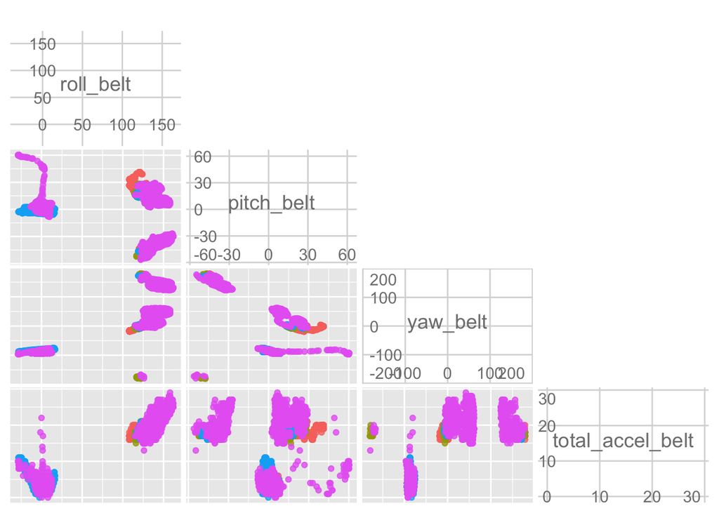

```r
belt <- grepl("_belt|classe", names(training)); beltDS <- training[, names(training)[belt], with=F]
require(GGally)
ggpairs(data=beltDS, mapping = aes(color=classe), columns=c(1:4),
        axisLabels="internal",upper="blank", diag="blank",
        lower = list(continuous = wrap("points", alpha = 0.8)))
```

# Preprocessing data

The training set used to train the model will consist in 75% of the clean data set elements. The rest will be used as a test set for verifying the model.

```r
inTrain <- createDataPartition(y=training2$classe,
                               p=0.75, list=FALSE)
train <- training2[inTrain,]
test <- training2[-inTrain,]
dim(train)
```

```
## [1] 14718    53
```

```r
dim(test)
```

```
## [1] 4904   53
```

# Model training

```r
library(doMC)
registerDoMC(cores=detectCores()-1)
modFit <- train(classe~ .,data=train,method="rf",prox=TRUE)
modFit
```

```
## Random Forest
##
## 14718 samples
##    52 predictor
##     5 classes: 'A', 'B', 'C', 'D', 'E'
##
## No pre-processing
## Resampling: Bootstrapped (25 reps)
## Summary of sample sizes: 14718, 14718, 14718, 14718, 14718, 14718, ...
## Resampling results across tuning parameters:
##
##   mtry  Accuracy   Kappa
##    2    0.9896774  0.9869427
##   27    0.9893740  0.9865601
##   52    0.9781144  0.9723178
##
## Accuracy was used to select the optimal model using  the largest value.
## The final value used for the model was mtry = 2.
```

```r
modFit$finalModel
```

```
##
## Call:
##  randomForest(x = x, y = y, mtry = param$mtry, proximity = TRUE)
##                Type of random forest: classification
##                      Number of trees: 500
## No. of variables tried at each split: 2
##
##         OOB estimate of  error rate: 0.65%
## Confusion matrix:
##      A    B    C    D    E  class.error
## A 4184    1    0    0    0 0.0002389486
## B   20 2821    7    0    0 0.0094803371
## C    0   18 2546    3    0 0.0081807557
## D    0    0   38 2372    2 0.0165837479
## E    0    0    2    4 2700 0.0022172949
```

```r
pred <- predict(modFit,test);
table(pred,test$classe)
```

```
##
## pred    A    B    C    D    E
##    A 1394    4    0    0    0
##    B    1  944    8    0    0
##    C    0    1  847   13    0
##    D    0    0    0  790    2
##    E    0    0    0    1  899
```

# Validation sample prediction

As a final step, the second data set or validation sample consisting in 20 obserations will be used to further verify the model. This new data set will be cleaned and formatted in exactly the same way as the initial testing data, as specified in the “Predictor selection and exploratory data analysis” section.

```r
predictors <- names(validation)[!isNotPredictor]
validation2 <- validation[, predictors, with=F]
length(names(validation2)) # 53
```

```
## [1] 53
```

```r
validation2 <- validation2[, (c(1:52)) := lapply(.SD, as.numeric), .SDcols = c(1:52)]
str(validation2)
```

```
## Classes 'data.table' and 'data.frame':   20 obs. of  53 variables:
##  $ roll_belt           : num  123 1.02 0.87 125 1.35 -5.92 1.2 0.43 0.93 114 ...
##  $ pitch_belt          : num  27 4.87 1.82 -41.6 3.33 1.59 4.44 4.15 6.72 22.4 ...
##  $ yaw_belt            : num  -4.75 -88.9 -88.5 162 -88.6 -87.7 -87.3 -88.5 -93.7 -13.1 ...
##  $ total_accel_belt    : num  20 4 5 17 3 4 4 4 4 18 ...
##  $ gyros_belt_x        : num  -0.5 -0.06 0.05 0.11 0.03 0.1 -0.06 -0.18 0.1 0.14 ...
##  $ gyros_belt_y        : num  -0.02 -0.02 0.02 0.11 0.02 0.05 0 -0.02 0 0.11 ...
##  $ gyros_belt_z        : num  -0.46 -0.07 0.03 -0.16 0 -0.13 0 -0.03 -0.02 -0.16 ...
##  $ accel_belt_x        : num  -38 -13 1 46 -8 -11 -14 -10 -15 -25 ...
##  $ accel_belt_y        : num  69 11 -1 45 4 -16 2 -2 1 63 ...
##  $ accel_belt_z        : num  -179 39 49 -156 27 38 35 42 32 -158 ...
##  $ magnet_belt_x       : num  -13 43 29 169 33 31 50 39 -6 10 ...
##  $ magnet_belt_y       : num  581 636 631 608 566 638 622 635 600 601 ...
##  $ magnet_belt_z       : num  -382 -309 -312 -304 -418 -291 -315 -305 -302 -330 ...
##  $ roll_arm            : num  40.7 0 0 -109 76.1 0 0 0 -137 -82.4 ...
```

[output cut: 40 more lines]

Predicted values for the validation set:

```r
predict(modFit,validation2);
```

```
##  [1] B A B A A E D B A A B C B A E E A B B B
## Levels: A B C D E
```

The following plot shows the accuracy of the prediction for the first four belt-related variables from the test set, similar to the plot of the exploratory data analysis section:

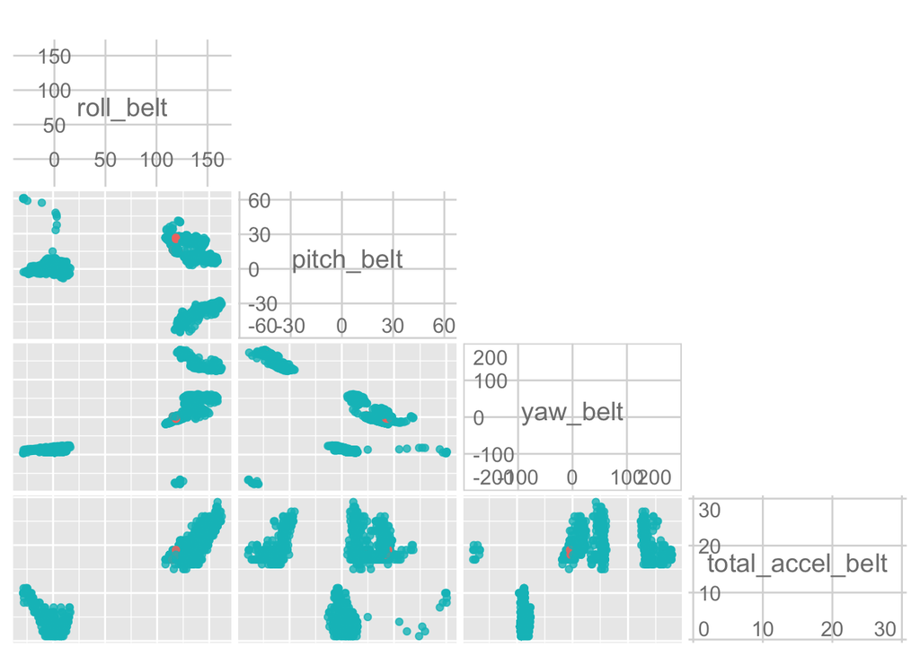

```r
belt <- grepl("_belt|classe", names(test)); beltDS <- test[, names(test)[belt], with=F]
beltDS$predictRight <- pred==test$classe
ggpairs(data=beltDS, mapping = aes(color = predictRight), columns=c(1:4),
        axisLabels="internal",upper="blank", diag="blank",
        lower = list(continuous = wrap("points", alpha = 0.8)))
```

# Conclusions

Further refinements on the model could be performed taking into account the most important predictors from the importance ranking. The following ffeature plot shows predictors over 50% of accuracy of classification.

```r
varImp(modFit)
```

```
## rf variable importance
##
##   only 20 most important variables shown (out of 52)
##
##                      Overall
## roll_belt             100.00
## yaw_belt               84.29
## magnet_dumbbell_z      73.63
## magnet_dumbbell_y      65.96
## pitch_belt             64.96
## pitch_forearm          58.08
## roll_forearm           56.73
## magnet_dumbbell_x      52.98
## accel_dumbbell_y       48.44
## magnet_belt_z          46.44
## roll_dumbbell          45.51
## accel_belt_z           44.16
## magnet_belt_y          42.74
## accel_dumbbell_z       37.45
## accel_forearm_x        34.59
## roll_arm               34.13
## yaw_dumbbell           30.98
## accel_dumbbell_x       30.41
## gyros_dumbbell_y       30.38
## total_accel_dumbbell   29.33
```

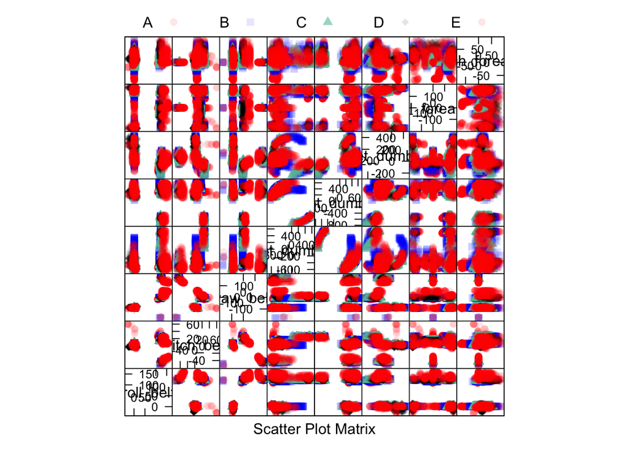

```r
list50pc <- c("roll_belt", "yaw_belt", "magnet_dumbbell_z", "magnet_dumbbell_y",
            "pitch_forearm", "pitch_belt", "roll_forearm", "magnet_dumbbell_x")
ds50pc <- test[, names(test) %in% list50pc, with=F]; ds50pc$classe <- test$classe
require(AppliedPredictiveModeling); transparentTheme(trans = .1)
featurePlot(x = ds50pc[, c(1:8), with=F], y = ds50pc$classe,
            plot = "pairs", auto.key = list(columns = 5))
```